# 08-effective-communication

Professor Shannon Ellis

2023-10-26

# Effective Communication

## Q&A

> Q: for the last part of lecture 07, I tried glance(m_ht_wt) but it didn’t work because m_ht_wt doesn’t exist. Is “m_ht_wt” supposed be a model?  
> A: Yup, this model was the height by weight model:

```r
m_ht_wt <- linear_reg() |>
  set_engine("lm") |>
  fit(Height_in ~ Width_in, data = pp)
```

> Q: I was not too sure what was going on when talking about the relationship between painting height and school.  
> A: I don’t think you were the only one confused! Briefly here (and I’m happy to chat more before/after class and in OH), we were looking to determine/quantify the relationship between the size (height) of a painting and the school from which the painting originated. This was an example of having more than two categories for a categorical (factor) predictor. The important points were undersatnding that each level is compared to the baseline *and* the linear model that results from multiple categories. Part 4 of the lab gets into this a bit more too. Definitely follow up if you’re unsure after doing that part of the lab!

> Q: How do you calculate the linear regression model when you have non-numeric values? For example, on lab 04, when it asks to calculate the linear regression model by gender, the gender appears only as male and female. Suppose male is 1 and female is 0 (interpreted by the function), then male linear regression model is y =ax + 1?  
> A: Close! the “1” would be plugged in as the value of x (in what you suggested)m not for the intercept. So the function would be $y=\beta_1*1 + \beta_0$

## Course Announcements

- Lab04 due Friday
- HW02 due Monday
- Practice Midterms Now Available
  - answers posted next week
- **Midterm Exam**
  - will cover material through “Multiple Linear Regression”
  - will be released/posted next Friday *after* lab
  - will be **due Monday Nov 6th at 11:59 PM**
  - will be an Rmd document and submitted via GitHub (like everything so far)
  - will be completed *individually* (open Notes; open Internet)
- [Link for Later](https://docs.google.com/forms/d/e/1FAIpQLSc9dyocixWJGHjmU3P8Peli5FePchGBFoZOfw93ibnjWWJ8xg/viewform?usp=sf_link)

[figure not shown]

## Agenda

- Communicating for your audience
- Oral Communication
- Written Communication
- Visual Communication

## Suggested Reading

- Bookdown [Section 2.6 R Code Chunks & inline R code](https://bookdown.org/yihui/rmarkdown/r-code.html)
- Bookdown [Chapter 3: Documents](https://bookdown.org/yihui/rmarkdown/html-document.html)
- Will Chase’s rstudio::conf2020 talk: “The Glamour of Graphics” [[slides](https://www.williamrchase.com/slides/assets/player/KeynoteDHTMLPlayer.html)] [[video](https://www.youtube.com/watch?v=h5cTacaWE6I)]

# Consider your audience

## What does this mean?

❓ What does it mean to “consider your audience?”

Simply: **You do the work so they don’t have to.**

…also the aesthetic-usability effect exists.

## What’s the right level?

**General Audience**  
✔ background  
🚫 limit technical details  
🎉 emphasize take-home

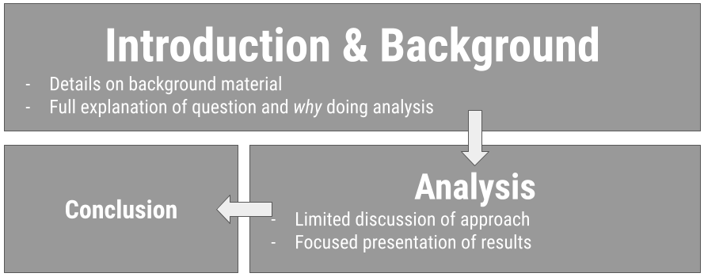

**Technical Audience**  
⬇ limit background  
💻 all-the-details  
🎉 emphasize take-home

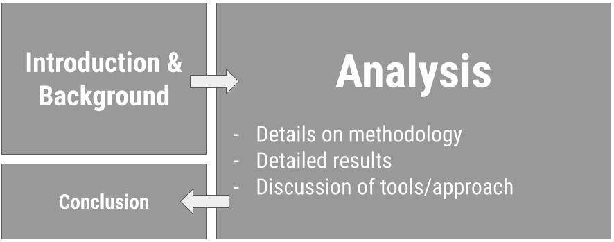

## Considerations

- **Platform**: written? oral?
- **Setting**: informal? formal?
- **Timing**: never go over your time limit!

## Storytelling

- Stories have a beginning, a middle, and an end.
- Stories do not need *every* detail of what you’ve tried
- Reports and presentations should tell a story
- Planning out your report/presentation can help
- Hold the audience’s attention with what needs to be said; do so effectively
- Tell your audience why they should care; why it matters
- You should explain your choices and the “why”

## Choose informative titles

On **presentations**: Balance b/w short and informative (goal: concise)

Avoid: “Analyzing NHANES”

Better: “Data from the NHANES study shows that diet is related to overall health”

On **visualizations**: emphasize the take-home! (what’s learned or what action to take)

Avoid: “Boxplot of gender”

Better: “Twice as many females as males included for analysis”

Avoid: “Tickets vs. Time”

Better: “Staff unable to respond to incoming tickets; need to hire 2 FTEs”

# Effective Oral Communication

Brainstorm: Advice You’ve Been Given?

## Student responses

| Advice you've received |
| --- |
| consider your audience |
| speak organizedly and logically |
| A narrative format is preferable to an enumeration or a nonlinear presentation such as what would arise from reading off an infographic, for example. |
| Be clear and direct! |
| Don't say filler words like "uhm" "like". Take a pause instead |
| Consciously speak slowly than you normally do (for fast talkers) |
| speak confidently and know material well enough to sound natural/not just memorize material |
| interact with the audience |
| Talk slowly and clearly |
| Put yourself in the shoes of your audience |
| Speak clearly at a good pace (not too fast or slow), make eye contact and engage with your audience |
| Enunciation, proper volume, etc. |
| I tend to speak in long sentences which can confuse the audience. |
| Talk slower and clearer. Enunciation. Eye contact while talking. Avoid filler words. |
| speak clearly, slow down if you need to, don't just read off slides when presenting |
| be sure to point out areas of interest on your plots and explain them |
| Use simply words if possible |
| Speaking slowly at someone |
| Don't assume the audience know the same thing (like the research background or the research design) as you do. Another thing is: try to make sentence as simple as possible. |
| Take moments to pause in between you sentences if you get lost. |
| Speak slowly and clearly |
| Keep it engaging, involve audience participation, make eye contact, be confident |
| Talk clearly and stick with the theme |
| Cater to your audience. Be conscious of what they know and don't know. |
| Use appropriate font. |
| Speak clearly and slow down when you're picking up a fast pace. |

## Presentations are for listening

- Advantage: words to explain out loud what you’re showing
- You are presenting for the person in the back of the room.

To accomplish:

- don’t read directly off slides
- repetition is ok: tell what you’re going to tell them, tell them, tell them what you told them
- use animation to build your story (not to distract)
- introduce your axes
- text/labels larger
- watch your speech speed
- practice!

## For Example: A Happy Ending for (almost) everyone in Little Red Riding Hood

- Red Riding Hood (RRH) has to walk 0.54 mi from Point A (home) to Point B (Grandma’s)
- RRH meets Wolf who (1) runs ahead to Grandma’s, (2) eats her, and (3) dresses in her clothes
- RRH arrives at Grandmas at 2PM, asks her three questions
- Identified problem: after third question, Wolf eats RRH
- Solution: vendor (Woodsman) employs tool (ax)
- Expected outcome: Grandma and RRH alive, wolf is not

# Little Red Riding Hood

# Effective Written Communication

Brainstorm: Advice You’ve Been Given?

## Student responses

| Advice you've received |
| --- |
| When sending a status update on a project to people in my team, I often had a habit of over explaining things such as specific terms or what a specific p-value indicates, etc. and it was redundant to … |
| NA |
| Be as concise as possible while getting your point across |
| no need to write full sentences for bullet points |
| write in a concise manner, don’t use big words unless it’s relevant |
| keep things succinct and write in a neutral tone |
| Bold or italicize important ideas/ key words in long writing |
| Main idea sentence in the beginning of your text (report, essay, email). |
| Refrain from using the first person. Talk in the past-tense |
| Use grammarly |
| Watch repetition of certain words. Occasionally change the structure of sentences. Know your audience. |
| Dont be too repetitive and Don’t have run on long sentences and get caught up in the details too much - I do that a lot :// |
| Avoid ambiguity, have someone else proof read to double check what you've written, try not to make your sentences too wordy. |
| Write for your audience, avoid overuse of jargon and if necessary be sure to define the terms in a way appropriate for how you’re actually using them. |
| Be clear and concise with the points you're trying to make and don't lose them with sentences that run on for too long |
| Be concise and use as few words to effectively get point across. Don't go off on tangents. |
| Organize using subheadings, highlight main points using bold or colors if appropriate, vary sentence structure |
| make your sentences simpler to understand |
| When giving a status report to a technical team, no need to over-explain terms. It is a lot of times effective to make a concise bullet point list such as p value= x, correlation coefficinet = y, inst… |
| Write in words that the readers will understand, and do not assume that the readers will know what you mean. |
| use an outline to help organize the order of your paper. it helps you figure out where to place images, plots, and text |
| Organize arguments, don't be overly repetitive |

## Benefits of written communciation

Your audience has time to process…but the explanation has to be there!

Visually: more on a single visualization

Yes, often there are different visualizations for reports/papers than for presentations/lectures.

## When you have time to digest (read)

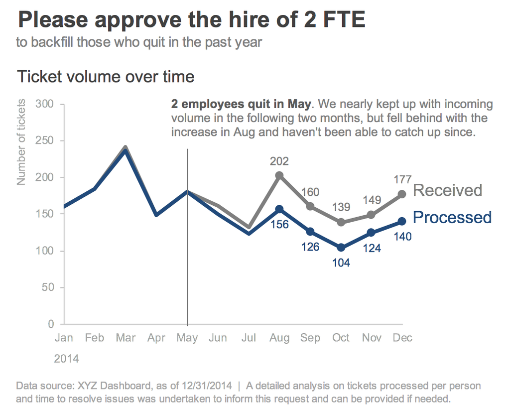

❓ What makes this an effective visualization for a written communication?”

Source: [Storytelling wtih data](https://www.storytellingwithdata.com/book/downloads) by cole nussbaumer knaflic

## Written Explanations

- Visualizations should be explained/interpreted
- Models should be explained
  - should be clear what question is being answered
  - what conclusions is being drawn
  - and what numbers were used to draw that conclusion

## Data Science Reports in .Rmd

- As concise as possible
- Necessary details (for your audience); nothing more
  - Be sure that the knit output contains what you intended (plots displayed; headers etc.)
  - …and does NOT display stuff that doesn’t need to be there (messages/warnings suppressed, brainstorming, etc.)
- Typical Sections: Introduction/Background, Setup, Data, Analysis, Conclusion, References

## Controlling HTML document settings

- Table of Contents

```
---
title: "Document Title"
output:
  html_document:
    toc: true
    toc_float: true
---
```

- Theme

```
---
title: "Document Title"
output:
  html_document:
    theme: united
    highlight: tango
---
```

- Figure Options

```
---
title: "Document Title"
output:
  html_document:
    fig_width: 7
    fig_height: 6
    fig_caption: true
---
```

- Code Folding

```
---
title: "Document Title"
output:
  html_document:
    code_folding: hide
---
```

## Controlling code chunk output

- Specified in the curly braces, separated by commas
- `eval`: whether to execute the code chunk
- `echo`: whether to include the code in the output
- `warning`, `message`, and `error`: whether to show warnings, messages, or errors in the knit document
- `fig.width` and `fig.height`: control the width/height of plots
- Controlling for the whole document:

```
knitr::opts_chunk$set(fig.width = 8, collapse = TRUE)
```

## Editing & Proofreading

- Did you end up telling a story?
  - Things missing?
  - Things to delete?
- Do not fall in love with your words/code/plots
- Do spell check
- Do read it over before sending/presenting/submitting

## Aside: Citing Sources

**When are citations needed?**

> “We will be doing our analysis using two different data sets created by two different groups: Donohue and Mustard + Lott, or simply Lott”

> “What turned from the idea of carrying firearms to protect oneself from enemies such as the British monarchy and the unknown frontier of North America has now become a nationwide issue.”

> “Right to Carry Laws refer to laws that specify how citizens are allowed to carry concealed handguns when they’re away from home without a permit”

> “In this case study, we are examining the relationship between unemployment rate, poverty rate, police staffing, and violent crime rate.”

> “In the United States, the second amendment permits the right to bear arms, and this law has not been changed since its creation in 1791.”

> “The Right to Carry Laws (RTC) is defined as”a law that specifies if and how citizens are allowed to have a firearm on their person or nearby in public.””

**Reminder**: You do NOT get docked points for citing others’ work. You can be at risk of AI Violation if you don’t. **When in doubt, give credit.**

## Footnotes in .Rmd

How to specify a footnote in text:

```
Here is some body text.[^1]
```

How to include the footnote’s reference:

```
[^1]: This footnote will appear at the bottom of the page.
```

Note: .bib files can be included with BibTeX references using the `bibliography` parameter in your YAML

# Effective Visual Communication

Brainstorm: Advice You’ve Been Given?

## Student Responses

| Advice you've received |
| --- |
| Don’t make slides overly colorful |
| no borders on plots, graphs.don't write the whole info on one slide. take advantage of white space |
| use images to help audience understand |
| Highlight important points in visualization. |
| don’t write everything on slides, just main points, try to use pictures that model/reflect/support talking points |
| use a legend for graphs |
| make sure your plot is relevant to the point you are trying to make |
| reduce the number of words on the slide |
| It should be easy to understand/digest relatively quickly, only put absolutely necessary/relevant things |
| Pick a font and size for body+headings and commit to it |
| Try to keep the design minimalistic and aesthetic, no cognitive overload that way. |
| Title your plots & graphs |
| Images/visuals should help strengthen your presentation/story, not distracting from it |
| Use lots of pictures! |
| It's better to have meaningful and intuitive color selection. |
| Specific graphs are more beneficial to a technical audience, while others are better for a non-technical one. My coworkers like graphs such as boxplots, but when presenting to partners, I have found t… |
| Complementary colors, appropriate graphs for the type of information you have and want to get across, neat and not cluttered |
| Concise and clear, use colors and space effectively |
| Use color responsibly in graphs/tables, make text large enough for everyone in the room to see, don't overload slides with information |
| dont put too much words |
| Don’t put too many animations (if any) |
| Less is more. Too much can distract and detract from the main point |
| good contrast color between background and text |
| make clear visual guide, don’t make it too complicated |
| Avoid neon colors |
| Keep accessibility in mind when presenting visuals. (e.g. using texture instead of color, image descriptions, etc.) |
| Make presentations look cleaner. Seems like you know what youre talking about. |

## The *Glamour* of Graphics

- builds on top of the grammar (*components*) of a graphic
- considerations for the *design* of a graphic
- color, typography, layout
- going from accurate to 😍effective

These ideas and slides are all modified from Will Chase’s rstudio::conf2020 [slides](https://www.williamrchase.com/slides/assets/player/KeynoteDHTMLPlayer.html)/talk

## Left-align titles at top-left

**😬 Accurate**

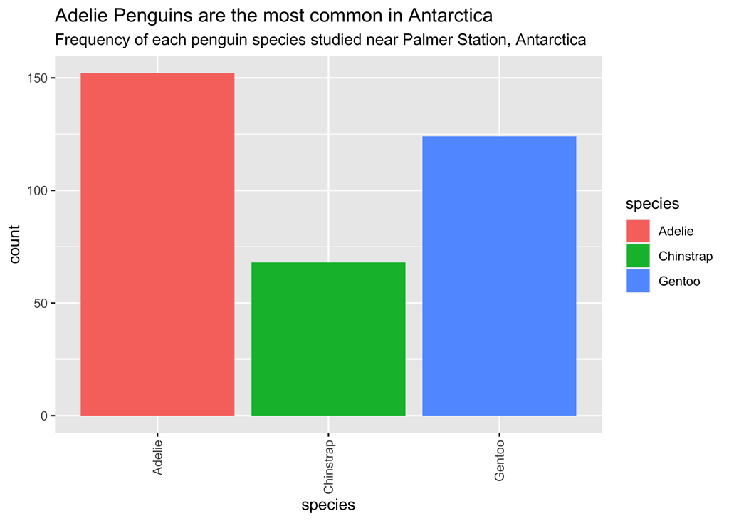

```r
ggplot(penguins, aes(x = species, fill = species)) +
  geom_bar() +
  labs(title = "Adelie Penguins are the most common in Antarctica",
       subtitle = "Frequency of each penguin species studied near Palmer Station, Antarctica") +
  theme(axis.text.x = element_text(angle = 90, vjust = 0.5, hjust = 1))
```

**😍 Effective**

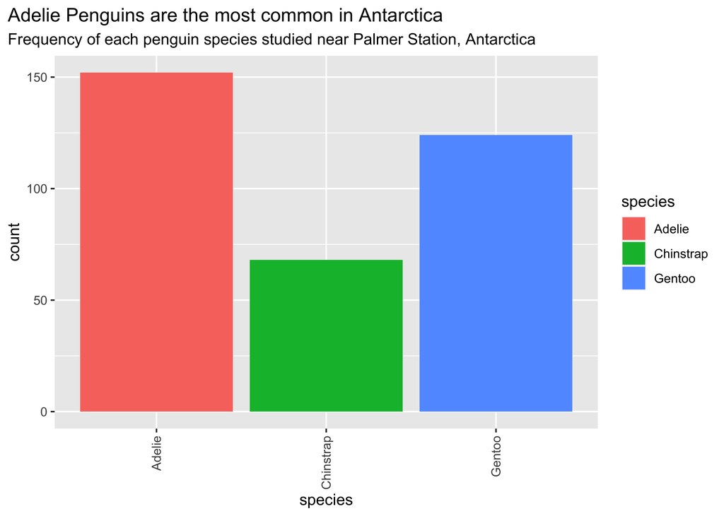

```r
ggplot(penguins, aes(x = species, fill = species)) +
  geom_bar() +
  labs(title = "Adelie Penguins are the most common in Antarctica",
       subtitle = "Frequency of each penguin species studied near Palmer Station, Antarctica") +
  theme(axis.text.x = element_text(angle = 90, vjust = 0.5, hjust = 1),
        plot.title.position = "plot")
```

## Avoid head-tilting

**😬 Accurate**

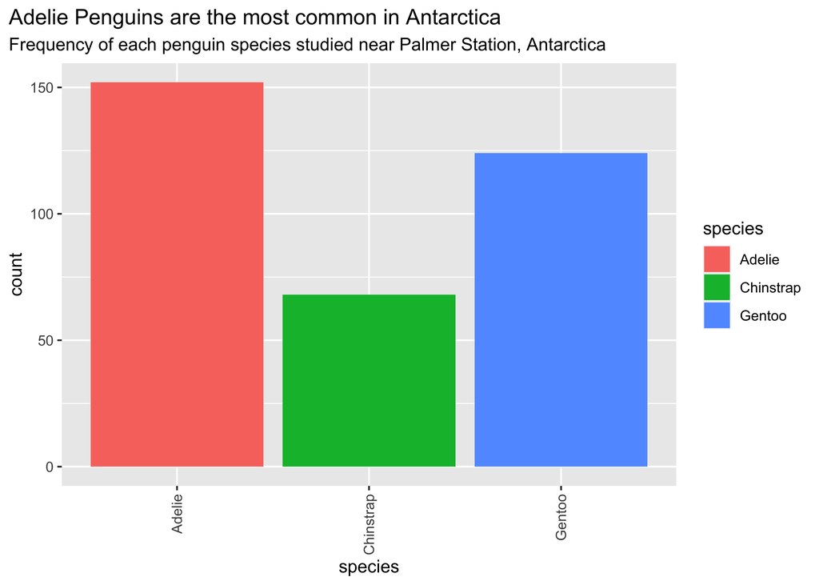

```r
ggplot(penguins, aes(x = species, fill = species)) +
  geom_bar() +
  labs(title = "Adelie Penguins are the most common in Antarctica",
       subtitle = "Frequency of each penguin species studied near Palmer Station, Antarctica") +
  theme(axis.text.x = element_text(angle = 90, vjust = 0.5, hjust = 1),
        plot.title.position = "plot")
```

**😍 Effective**

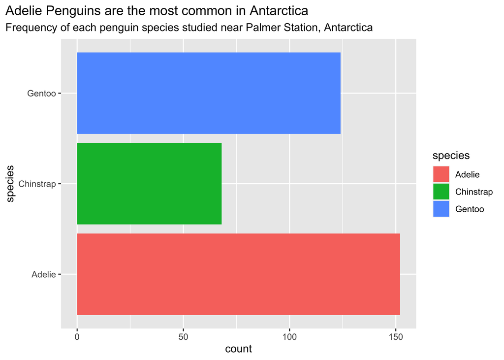

```r
ggplot(penguins, aes(y = species, fill = species)) +
  geom_bar() +
  labs(title = "Adelie Penguins are the most common in Antarctica",
       subtitle = "Frequency of each penguin species studied near Palmer Station, Antarctica") +
  theme(plot.title.position = "plot")
```

## Borders & Backgrounds: 👎

**😬 Accurate**

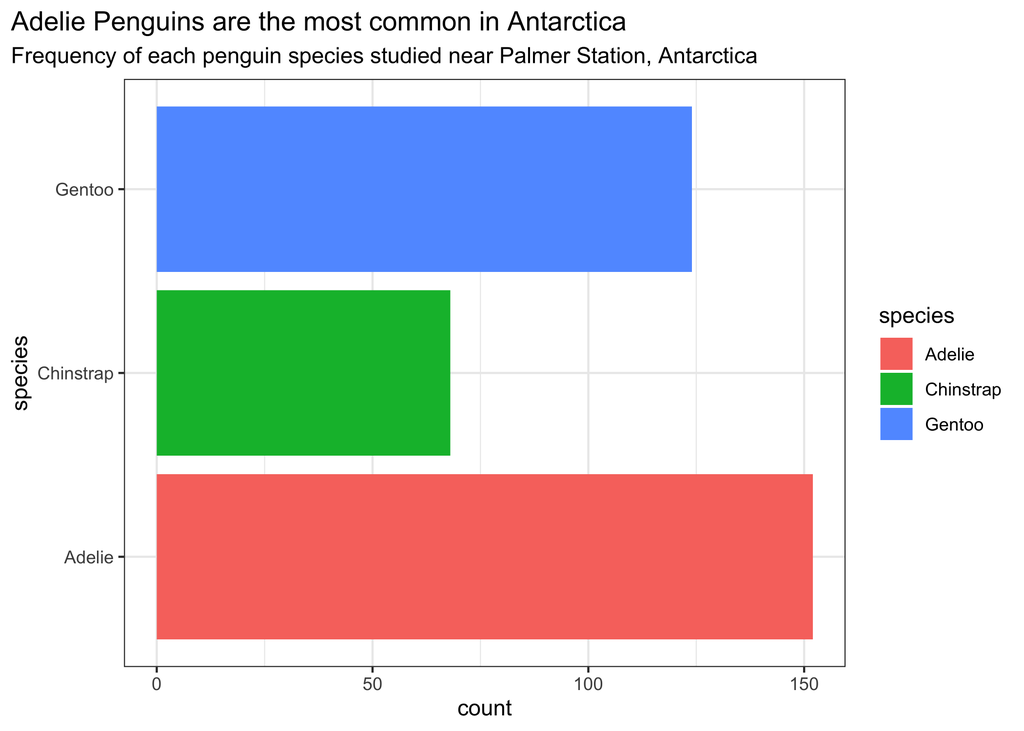

```r
ggplot(penguins, aes(y = species, fill = species)) +
  geom_bar() +
  labs(title = "Adelie Penguins are the most common in Antarctica",
       subtitle = "Frequency of each penguin species studied near Palmer Station, Antarctica") +
  theme_bw() +
  theme(plot.title.position = "plot")
```

**😍 Effective**

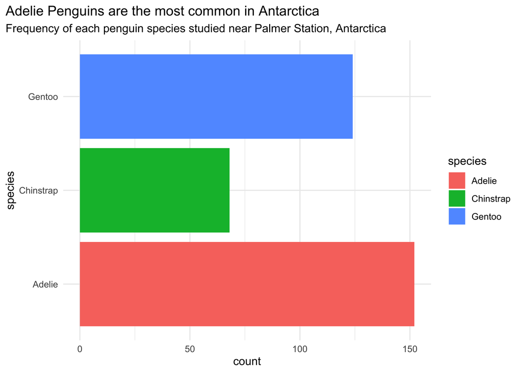

```r
ggplot(penguins, aes(y = species, fill = species)) +
  geom_bar() +
  labs(title = "Adelie Penguins are the most common in Antarctica",
       subtitle = "Frequency of each penguin species studied near Palmer Station, Antarctica") +
  theme_minimal() +
  theme(plot.title.position = "plot")
```

## Organize & Remove/Lighten as much as possible

**😬 Accurate**

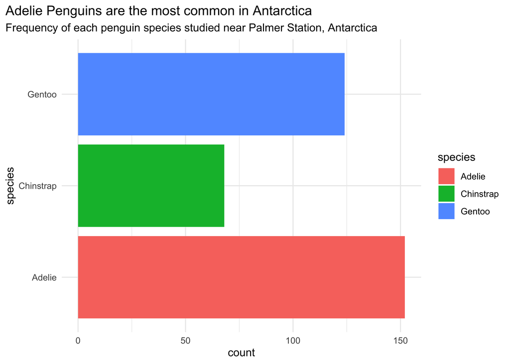

```r
ggplot(penguins, aes(y = species, fill = species)) +
  geom_bar() +
  labs(title = "Adelie Penguins are the most common in Antarctica",
       subtitle = "Frequency of each penguin species studied near Palmer Station, Antarctica") +
  theme_minimal() +
  theme(plot.title.position = "plot")
```

**😍 Effective**

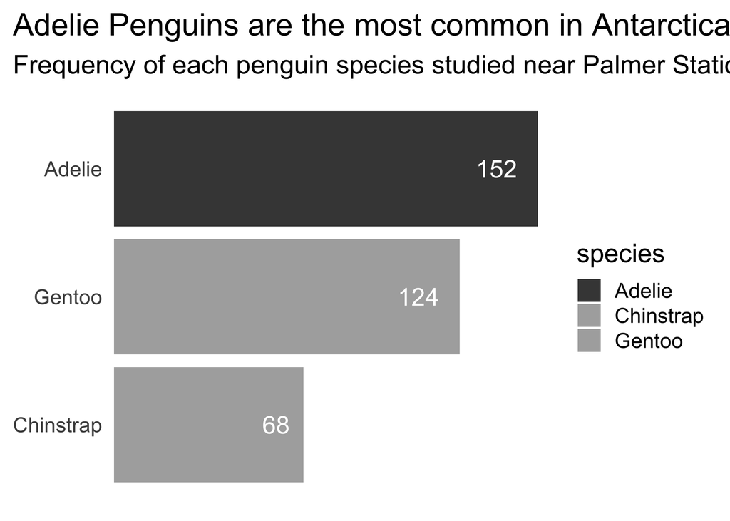

```r
ggplot(penguins, aes(y = fct_rev(fct_infreq(species)), fill = species)) +
  geom_bar() +
  geom_text(stat='count', aes(label=..count..), hjust = 1.5, color = "white", size = 6) +
  scale_x_continuous(expand = c(0, 0)) +
  scale_fill_manual(values = c("#454545", rep("#adadad", 2))) +
  labs(title = "Adelie Penguins are the most common in Antarctica",
       subtitle = "Frequency of each penguin species studied near Palmer Station, Antarctica") +
  theme_minimal(base_size = 18) +
  theme(axis.text.x = element_blank(),
        plot.title.position = "plot",
        panel.grid.major = element_blank(), panel.grid.minor = element_blank(),
        axis.title = element_blank())
```

## Legends suck

**😬 Accurate**

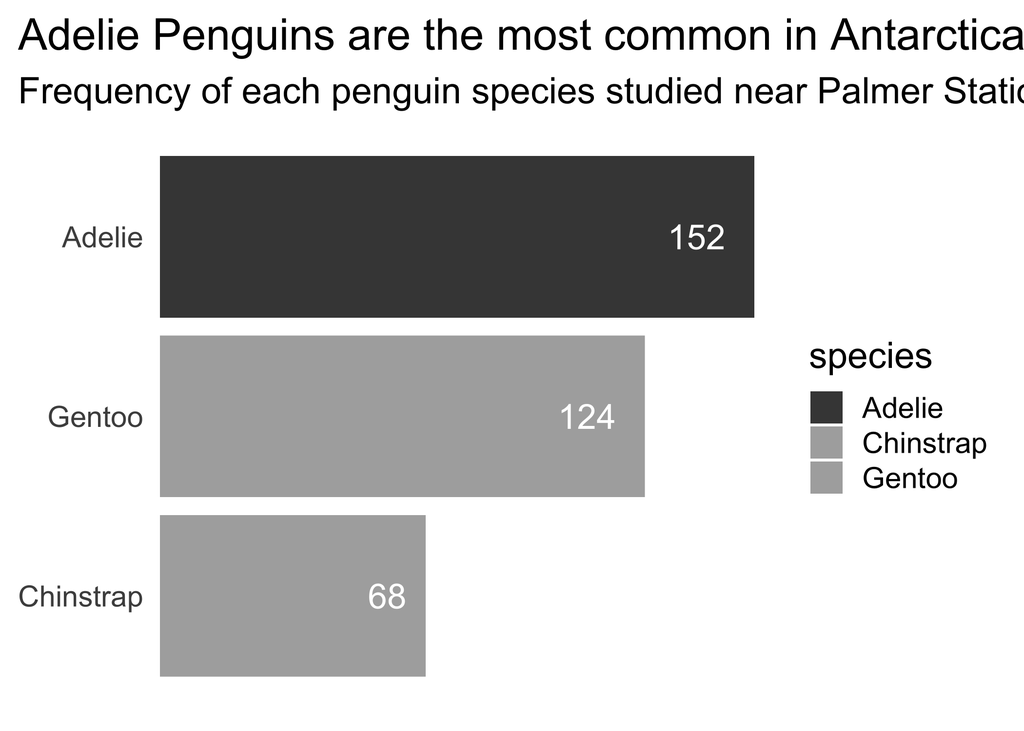

```r
ggplot(penguins, aes(y = fct_rev(fct_infreq(species)), fill = species)) +
  geom_bar() +
  geom_text(stat='count', aes(label=..count..), hjust = 1.5, color = "white", size = 6) +
  scale_x_continuous(expand = c(0, 0)) +
  scale_fill_manual(values = c("#454545", rep("#adadad", 2))) +
  labs(title = "Adelie Penguins are the most common in Antarctica",
       subtitle = "Frequency of each penguin species studied near Palmer Station, Antarctica") +
  theme_minimal(base_size = 18) +
  theme(axis.text.x = element_blank(),
        plot.title.position = "plot",
        panel.grid.major = element_blank(), panel.grid.minor = element_blank(),
        axis.title = element_blank())
```

**😍 Effective**

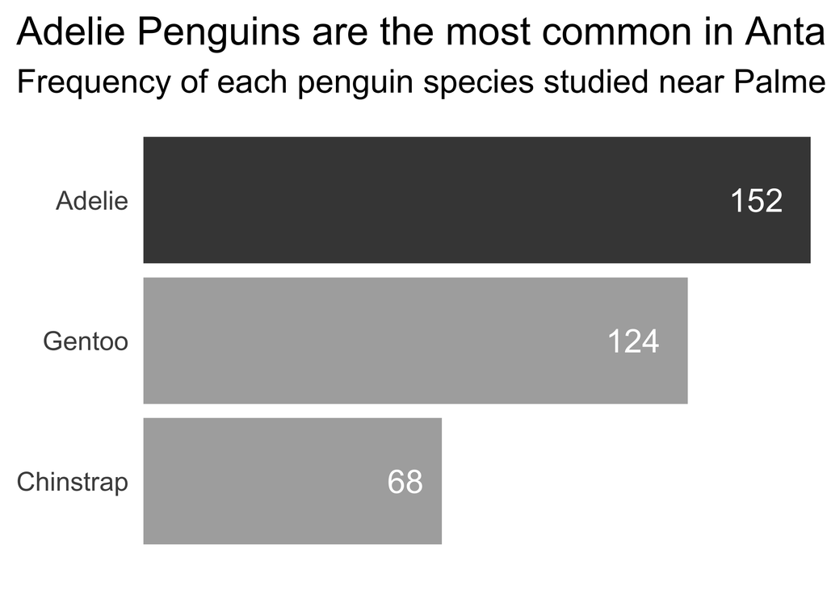

```r
ggplot(penguins, aes(y = fct_rev(fct_infreq(species)), fill = species)) +
  geom_bar() +
  geom_text(stat='count', aes(label=..count..), hjust = 1.5, color = "white", size = 7) +
  scale_x_continuous(expand = c(0, 0)) +
  scale_fill_manual(values = c("#454545", rep("#adadad", 2))) +
  labs(title = "Adelie Penguins are the most common in Antarctica",
       subtitle = "Frequency of each penguin species studied near Palmer Station, Antarctica") +
  theme_minimal(base_size = 20) +
  theme(axis.text.x = element_blank(),
        plot.title.position = "plot",
        panel.grid.major = element_blank(), panel.grid.minor = element_blank(),
        axis.title = element_blank(),
        legend.position = "none")
```

## Additional Guidance

- White space is like garlic - take the amount you need and triple it
- Fonts Matter
- Use Color Effectively

https://cogs137.github.io/website/